# Anomaly Detection - EDA Assignment V

Ram Subramanian (RS3955)

10/13/2019

## K-means Clustering On Improved Healthcare Features For Abuse Detection

####In addition to the features like Ratio of Discharges and Deviations of charges and payments for DRG-Provider combinations at State, Zip and HRR level, new features will be added as part of this assignment to perform peer comparisons on payments and charges among providers of the same state followed by K-means clustering to identify anomalous groups.

```r
#Import Libraries and load feature-engineered data set from the previous assignment on healthcare abuse detection
library(dplyr)
```

```r
library(ggplot2)
library(data.table)
library(tidyverse)
library(stringr)
library(tidyr)
library(corrplot)
library(FactoMineR)
library(factoextra)
library(cluster)
library(psych)
setwd('C:/myfiles/Anomaly/assignment5')
payment_V2=read.csv('payment_V2.csv')
str(payment_V2)
```

```
## 'data.frame':    149817 obs. of  57 variables:
##  $ X                                   : int  1 2 3 4 5 6 7 8 9 10 ...
##  $ DRGbyHRR                            : int  1 2 2 2 2 2 2 2 2 2 ...
##  $ DRGbyZip                            : int  947 302 304 301 306 303 312 305 310 323 ...
##  $ DRGbyState                          : int  1 2 2 2 2 2 2 2 2 2 ...
##  $ Provider.Zip.Code                   : int  99508 35205 35211 35007 35233 35209 35901 35213 35631 36801 ...
##  $ DRG.Definition                      : Factor w/ 100 levels "039 - EXTRACRANIAL PROCEDURES W/O CC/MCC",..: 1 1 1 1 1 1 1 1 1 1 ...
##  $ Provider.Id                         : int  20017 10056 10103 10016 10033 10139 10046 10104 10006 10029 ...
##  $ Provider.Name                       : Factor w/ 3012 levels "ABBEVILLE GENERAL HOSPITAL",..: 30 2543 150 2292 2782 281 2117 2713 687 646 ...
##  $ Provider.Street.Address             : Factor w/ 3125 levels "#1 MEDICAL PARK DRIVE",..: 1514 2829 2608 75 2480 1137 2414 2768 1159 1098 ...
##  $ Provider.City                       : Factor w/ 1864 levels "ABBEVILLE","ABERDEEN",..: 44 154 154 14 154 154 598 154 553 1223 ...
##  $ Provider.State                      : Factor w/ 44 levels "AK","AL","AR",..: 1 2 2 2 2 2 2 2 2 2 ...
##  $ Hospital.Referral.Region.Description: Factor w/ 292 levels "AK - Anchorage",..: 1 2 2 2 2 2 2 2 2 2 ...
##  $ Total.Discharges                    : int  23 43 33 18 32 19 14 29 24 51 ...
##  $ Average.Covered.Charges             : num  34805 22862 51344 31633 35841 ...
```

[output cut: 43 more lines]

```r
#Grouping data to derive features on ratios
DRG_State_avg <- payment_V2 %>% group_by(DRG.Definition, Provider.State) %>%
  summarise( mean_average_covered_charges   = mean(Average.Covered.Charges),
             mean_average_total_payments    = mean(Average.Total.Payments),
             mean_average_medicare_payments = mean(Average.Medicare.Payments),
             mean_count_trans =n()
  )

head(DRG_State_avg,5)
```

```
## # A tibble: 5 x 6
## # Groups:   DRG.Definition [1]
##   DRG.Definition Provider.State mean_average_co~ mean_average_to~
##   <fct>          <fct>                     <dbl>            <dbl>
## 1 039 - EXTRACR~ AK                       34805.            8402.
## 2 039 - EXTRACR~ AL                       32044.            5744.
## 3 039 - EXTRACR~ AR                       27463.            6119.
## 4 039 - EXTRACR~ AZ                       33443.            7272.
## 5 039 - EXTRACR~ CA                       56095.            8388.
## # ... with 2 more variables: mean_average_medicare_payments <dbl>,
## #   mean_count_trans <int>
```

#### ADDITIONAL FEATURE ENGINEERING

#####Appending the average statistics back to the data to derive the features on ratios. Based on the feedback from the last assignment,the following features are created to perform peer comparisons on payments and charges among providers of the same state in addition to comparing individual provider’s covered charge to total charge through existing features

```r
payment_V3 <- payment_V2 %>%
  left_join(DRG_State_avg, by=c("DRG.Definition","Provider.State")) %>%
  mutate(
    ratio_average_covered_charges   = Average.Covered.Charges/mean_average_covered_charges,
    ratio_average_total_payments    = Average.Total.Payments/mean_average_total_payments,
    ratio_average_medicare_payments = Average.Medicare.Payments/mean_average_medicare_payments) %>%
  select(-mean_average_covered_charges,
         -mean_average_total_payments,
         -mean_average_medicare_payments,
         -mean_count_trans
  ) %>% arrange(Provider.Id, DRG.Definition)
```

#####Plotting features against DRG by state combinations

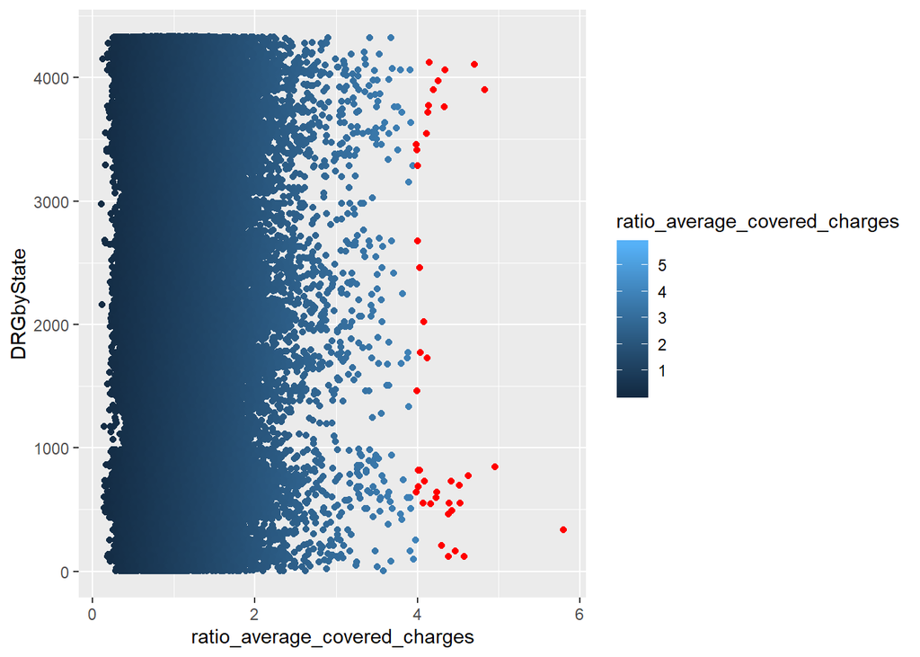

```r
#Plotting ratio_average_covered_charges vs DRG by State
payment_V3 <- as.data.table(payment_V3)
df_outlier <- payment_V3[payment_V3$ratio_average_covered_charges > 0.70*(max(payment_V3$ratio_average_covered_charges) - min(payment_V3$ratio_average_covered_charges[payment_V3$ratio_average_covered_charges> 0])),]
av1 <- payment_V3[,ratio_average_covered_charges,by=DRGbyState]
ggplot(data = av1,mapping = aes(y = DRGbyState,x = ratio_average_covered_charges,colour=ratio_average_covered_charges))+
  geom_point() +
  geom_point(data=df_outlier, aes(x=ratio_average_covered_charges,y=DRGbyState), color='red',size=1.5)
```

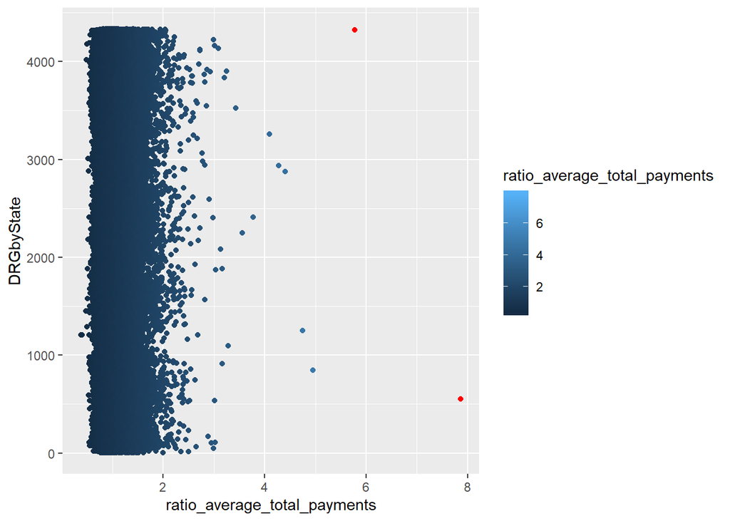

```r
payment_V3 <- as.data.table(payment_V3)
df_outlier <- payment_V3[payment_V3$ratio_average_total_payments > 0.70*(max(payment_V3$ratio_average_total_payments) - min(payment_V3$ratio_average_total_payments[payment_V3$ratio_average_total_payments> 0])),]
av1 <- payment_V3[,ratio_average_total_payments,by=DRGbyState]
ggplot(data = av1,mapping = aes(y = DRGbyState,x = ratio_average_total_payments,colour=ratio_average_total_payments))+
  geom_point() +
  geom_point(data=df_outlier, aes(x=ratio_average_total_payments,y=DRGbyState), color='red',size=1.5)
```

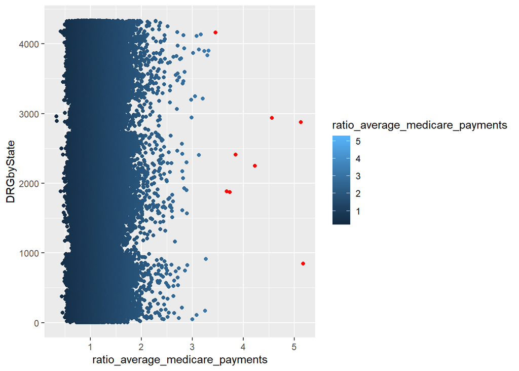

```r
#Plotting ratio_average_medicare_payments vs DRG by State
payment_V3 <- as.data.table(payment_V3)
df_outlier <- payment_V3[payment_V3$ratio_average_medicare_payments > 0.70*(max(payment_V3$ratio_average_medicare_payments) - min(payment_V3$ratio_average_medicare_payments[payment_V3$ratio_average_medicare_payments> 0])),]
av1 <- payment_V3[,ratio_average_medicare_payments,by=DRGbyState]
ggplot(data = av1,mapping = aes(y = DRGbyState,x = ratio_average_medicare_payments,colour=ratio_average_medicare_payments))+
  geom_point() +
  geom_point(data=df_outlier, aes(x=ratio_average_medicare_payments,y=DRGbyState), color='red',size=1.5)
```

```r
#Replacing all -ve values in features created for mean differences with 0 as we are interested in studying the data
#that are above the mean representing high charges

payment_corrected <- as.data.frame(payment_V3)
payment_corrected[ , c("ChargePayDiff_State", "ChargePayDiff_Zip", "ChargePayDiff_HRR","TotalPmtDiff_State","TotalPmtDiff_Zip","TotalPmtDiff_HRR","TotalChrgDiff_Zip")][ payment_corrected[ ,  c("ChargePayDiff_State", "ChargePayDiff_Zip", "ChargePayDiff_HRR","TotalPmtDiff_State","TotalPmtDiff_Zip","TotalPmtDiff_HRR","TotalChrgDiff_Zip")] < 0 ] <- 0
```

####CORRELATION STUDY OF THE RENOVATED SET OF FEATURES

```r
#Storing selected features for studying correlation in new data set
payment_cor <- select(payment_corrected,c("ChargePayDiff_State", "ChargePayDiff_Zip", "ChargePayDiff_HRR","TotalPmtDiff_State","TotalPmtDiff_Zip","TotalPmtDiff_HRR","DschrgRatio_State","SDTotalPmtDiff_State","SDTotalPmtDiff_Zip","SDTotalPmtDiff_HRR","SDTotalChrgDiff_State","TotalChrgDiff_Zip","ratio_average_covered_charges","ratio_average_total_payments","ratio_average_medicare_payments"))
str(payment_cor)
```

```
## 'data.frame':    149817 obs. of  15 variables:
##  $ ChargePayDiff_State            : num  754 0 0 3020 0 ...
##  $ ChargePayDiff_Zip              : num  0 0 0 0 0 0 0 0 0 0 ...
##  $ ChargePayDiff_HRR              : num  0 0 0 0 0 ...
##  $ TotalPmtDiff_State             : num  33.6 0 0 0 0 ...
##  $ TotalPmtDiff_Zip               : num  0 0 0 0 0 0 0 0 0 0 ...
##  $ TotalPmtDiff_HRR               : num  210.48 100.3 0 224.35 7.02 ...
##  $ DschrgRatio_State              : num  0.1035 0.0661 0.0661 0.0703 0.0279 ...
##  $ SDTotalPmtDiff_State           : num  0.0535 0 0 0 0 ...
##  $ SDTotalPmtDiff_Zip             : num  0 0 0 0 0 0 0 0 0 0 ...
##  $ SDTotalPmtDiff_HRR             : num  0.7071 0.7168 0 0.9491 0.0169 ...
##  $ SDTotalChrgDiff_State          : num  0.0456 0 0 0.2241 0 ...
##  $ TotalChrgDiff_Zip              : num  0 0 0 0 0 0 0 0 0 0 ...
##  $ ratio_average_covered_charges  : num  1.029 0.816 0.922 1.125 0.833 ...
##  $ ratio_average_total_payments   : num  1.006 0.942 0.946 0.989 0.997 ...
##  $ ratio_average_medicare_payments: num  1.036 0.903 0.955 1.001 1.036 ...
```

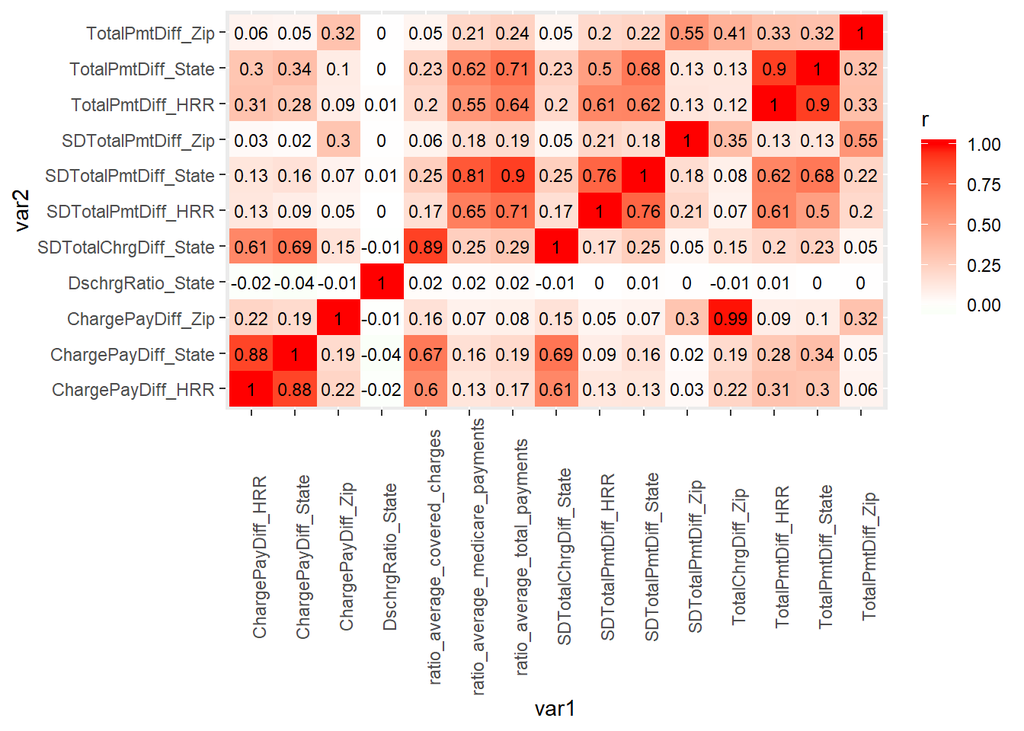

```r
#Visualizing the matrix to spot high correlations that indicate pairwise similarity
corMatrix = as.data.frame(cor(payment_cor))
corMatrix$var1 = rownames(corMatrix)
corMatrix %>%
  gather(key=var2,value=r,1:11)%>%
  ggplot(aes(x=var1,y=var2,fill=r))+
  geom_tile()+
  geom_text(aes(label=round(r,2)),size=3)+
  scale_fill_gradient2(low = 'green',high='red',mid = 'white')+
  theme(axis.text.x=element_text(angle=90))
```

#### PRINCIPAL COMPONENT ANALYSIS

#####Multiple variables measuring the same dimension should be replaced by the underlying factor or a representative variable before using Cluster analysis. We could combine correlated variables into a single component based on the results of a principal components analysis.

##### We standardize the variables so all of them are assigned equal weightage. Here, we are using the scale() function which will by default subtract mean and divide by standard deviation.

```r
#Standardization
df.scaled <- scale(payment_cor, center = TRUE, scale = TRUE)

#Compute the correlation matrix
res.cor <- cor(df.scaled)

#Calculate the eigenvectors/eigenvalues of the correlation matrix
res.eig <- eigen(res.cor)
res.eig
```

```
## eigen() decomposition
## $values
##  [1] 5.379632386 2.722003694 2.227675569 1.006800680 0.955828673
##  [6] 0.917002621 0.511273851 0.400253449 0.358306185 0.169557909
## [11] 0.114682784 0.108621026 0.068497142 0.051092810 0.008771221
##
## $vectors
##               [,1]        [,2]         [,3]         [,4]        [,5]
##  [1,] -0.229286252 -0.42276229  0.175178484 -0.065572344 -0.07467330
##  [2,] -0.126728861 -0.23422186 -0.511405393 -0.013641224  0.42799938
##  [3,] -0.220883732 -0.40936845  0.138725575 -0.068232462 -0.05151044
##  [4,] -0.347709365  0.14065359  0.038335857 -0.106073374 -0.02053392
##  [5,] -0.168180661  0.03202763 -0.400183857  0.007604577 -0.52952816
##  [6,] -0.336715554  0.15125780  0.024246884 -0.109089047 -0.04259022
##  [7,] -0.002488314  0.02096531  0.001740549  0.965829830  0.05223147
```

[output cut: 40 more lines]

```r
# Transpose eigeinvectors
eigenvectors.t <- t(res.eig$vectors)

# Transpose the adjusted data
df.scaled.t <- t(df.scaled)

# Compute the new dataset (matrix format)
df.new <- eigenvectors.t %*% df.scaled.t

# Transpose new data and rename columns
df.new <- t(df.new)
str(df.new)
```

```
##  num [1:149817, 1:15] 0.431 0.97 1.184 0.264 1.01 ...
```

```r
colnames(df.new) <- c("PC1", "PC2", "PC3", "PC4","PC5","PC6","PC7","PC8","PC9","PC10","PC11","PC12","PC13","PC14","PC15")

head(df.new)
```

```
##            PC1       PC2         PC3         PC4        PC5           PC6
## [1,] 0.4305359 0.5473409  0.07505135  1.36030585 0.26570355  0.0377865194
## [2,] 0.9701725 0.5546904 -0.11704532  0.59785682 0.16499748  0.2300650309
## [3,] 1.1841444 0.2213418 -0.08001105  0.64471469 0.09910189  0.2389675149
## [4,] 0.2638819 0.2885552  0.19645159  0.81087384 0.16833174 -0.2288279939
## [5,] 1.0102562 0.4426211 -0.08810932 -0.02311882 0.16014862 -0.0001406188
## [6,] 0.2984706 0.1756602  0.21551663  0.06346815 0.10319435 -0.4634982169
##             PC7        PC8        PC9      PC10        PC11       PC12
## [1,] -0.2298409  0.3391194 0.21961929 0.4903709  0.05862195 0.44842781
## [2,] -0.4440095  0.5858454 0.18579193 0.1392615  0.16328501 0.21408951
## [3,]  0.2002845 -0.2298903 0.03049731 0.1571664 -0.12020602 0.19316792
## [4,] -0.2975709  0.7571713 0.17095111 0.4993400  0.20101677 0.55655076
## [5,]  0.1964345 -0.4792668 0.15466539 0.3436722 -0.02061185 0.05759387
## [6,] -0.1610573  0.7301269 0.11806324 0.5002645  0.15872190 0.52310993
##              PC13        PC14          PC15
## [1,] -0.082983936  0.13809417 -0.0022667132
## [2,] -0.188352538  0.20394253 -0.0073929159
## [3,] -0.004742573 -0.05003677 -0.0053314962
## [4,] -0.118968926  0.21556657 -0.0007058480
## [5,] -0.114676040 -0.07952709 -0.0029408397
## [6,] -0.065846694  0.22197002  0.0002566147
```

```r
#Variances explained by each of the principal components
res.pca <- prcomp(df.new)
summary(res.pca)$importance
```

```
##                             PC1     PC2     PC3      PC4       PC5
## Standard deviation     2.319403 1.64985 1.49254 1.003395 0.9776649
## Proportion of Variance 0.358640 0.18147 0.14851 0.067120 0.0637200
## Cumulative Proportion  0.358640 0.54011 0.68862 0.755740 0.8194600
##                              PC6       PC7       PC8       PC9      PC10
## Standard deviation     0.9576025 0.7150342 0.6326559 0.5985868 0.4117741
## Proportion of Variance 0.0611300 0.0340800 0.0266800 0.0238900 0.0113000
## Cumulative Proportion  0.8806000 0.9146800 0.9413600 0.9652500 0.9765600
##                             PC11     PC12      PC13      PC14      PC15
## Standard deviation     0.3386485 0.329577 0.2617196 0.2260372 0.0936548
## Proportion of Variance 0.0076500 0.007240 0.0045700 0.0034100 0.0005800
## Cumulative Proportion  0.9842000 0.991440 0.9960100 0.9994200 1.0000000
```

#####We want to keep only the significant features and drop the insignificant ones so we keep the top 8 Principal components that capture up to 95% of the information

```r
df.new <- as.data.frame(df.new)
df.new_principal <- select(df.new,c(1:8))


#binding only the principal components to the orginal data set
payment_revised <- select(payment_corrected,c(1:18))
payment_revised <- cbind(payment_revised,df.new_principal)
str(payment_revised)
```

```
## 'data.frame':    149817 obs. of  26 variables:
##  $ X                                   : int  15 1010 2089 3625 5704 7355 9138 10025 12337 13631 ...
##  $ DRGbyHRR                            : int  3 287 540 828 1120 1410 1697 1942 2439 2727 ...
##  $ DRGbyZip                            : int  317 1396 2490 4096 5935 7589 8982 10019 12138 13512 ...
##  $ DRGbyState                          : int  2 46 90 134 178 222 264 306 389 433 ...
##  $ Provider.Zip.Code                   : int  36301 36301 36301 36301 36301 36301 36301 36301 36301 36301 ...
##  $ DRG.Definition                      : Factor w/ 100 levels "039 - EXTRACRANIAL PROCEDURES W/O CC/MCC",..: 1 2 3 4 5 6 7 8 10 11 ...
##  $ Provider.Id                         : int  10001 10001 10001 10001 10001 10001 10001 10001 10001 10001 ...
##  $ Provider.Name                       : Factor w/ 3012 levels "ABBEVILLE GENERAL HOSPITAL",..: 2359 2359 2359 2359 2359 2359 2359 2359 2359 2359 ...
##  $ Provider.Street.Address             : Factor w/ 3125 levels "#1 MEDICAL PARK DRIVE",..: 303 303 303 303 303 303 303 303 303 303 ...
##  $ Provider.City                       : Factor w/ 1864 levels "ABBEVILLE","ABERDEEN",..: 434 434 434 434 434 434 434 434 434 434 ...
##  $ Provider.State                      : Factor w/ 44 levels "AK","AL","AR",..: 2 2 2 2 2 2 2 2 2 2 ...
##  $ Hospital.Referral.Region.Description: Factor w/ 292 levels "AK - Anchorage",..: 3 3 3 3 3 3 3 3 3 3 ...
##  $ Total.Discharges                    : int  91 38 84 169 33 37 13 27 33 21 ...
##  $ Average.Covered.Charges             : num  32963 20313 38820 27345 17606 ...
##  $ Average.Total.Payments              : num  5777 4895 10260 6542 4596 ...
##  $ Average.Medicare.Payments           : num  4764 3866 9167 5438 3619 ...
##  $ city                                : Factor w/ 1814 levels "Abbeville","Aberdeen",..: 422 422 422 422 422 422 422 422 422 422 ...
##  $ state                               : Factor w/ 44 levels "AK","AL","AR",..: 2 2 2 2 2 2 2 2 2 2 ...
##  $ PC1                                 : num  0.431 0.97 1.184 0.264 1.01 ...
##  $ PC2                                 : num  0.547 0.555 0.221 0.289 0.443 ...
##  $ PC3                                 : num  0.0751 -0.117 -0.08 0.1965 -0.0881 ...
##  $ PC4                                 : num  1.3603 0.5979 0.6447 0.8109 -0.0231 ...
##  $ PC5                                 : num  0.2657 0.165 0.0991 0.1683 0.1601 ...
##  $ PC6                                 : num  0.037787 0.230065 0.238968 -0.228828 -0.000141 ...
##  $ PC7                                 : num  -0.23 -0.444 0.2 -0.298 0.196 ...
##  $ PC8                                 : num  0.339 0.586 -0.23 0.757 -0.479 ...
```

####K-MEANS CLUSTERING - CHOOSING A CLUSTER SOLUTION

```r
#Subsetting Principal Components into a data set for Clustering
data_cluster <- payment_revised[,c('PC1','PC2','PC3','PC4','PC5','PC6','PC7','PC8')]
```

#####We begin with an arbitrary assignment of observations to cluster centroids (here, 5-10) using K-means. And then update Cluster centers to minimize sum of squares from observations to cluster centers.

```r
set.seed(1000) #Setting Seed for reproducibility
k5 <-kmeans(data_cluster, centers=5,iter.max=1000, nstart = 25,algorithm="Lloyd")
set.seed(1000)
k6 <-kmeans(data_cluster, centers=6,iter.max=1000, nstart = 25,algorithm="Lloyd")
set.seed(1000)
k7 <-kmeans(data_cluster, centers=7,iter.max=1000, nstart = 25,algorithm="Lloyd")
set.seed(1000)
k8 <-kmeans(data_cluster, centers=8,iter.max=1000, nstart = 25,algorithm="Lloyd")
set.seed(1000)
k9 <-kmeans(data_cluster, centers=9,iter.max=1000, nstart = 25,algorithm="Lloyd")
set.seed(1000)
k10<-kmeans(data_cluster, centers=10,iter.max=1000, nstart = 25,algorithm="Lloyd")
#Here are the number of observations in the resulting clusters
k5[7]
```

```
## $size
## [1]   1617   1279  21203  17573 108145
```

```r
k6[7]
```

```
## $size
## [1]   1336  20481   6741  16055    924 104280
```

```r
k7[7]
```

```
## $size
## [1] 102689   1326    924   6680  15832  20314   2052
```

```r
k8[7]
```

```
## $size
## [1]   851  6507 21724  7506 91698  1945 18651   935
```

```r
k9[7]
```

```
## $size
## [1] 88132 21802  1908 20544  7202   940   328  6462  2499
```

```r
k10[7]
```

```
## $size
##  [1]   481  1010 20453  7437 85100   871  1901 22664  5799  4101
```

##### We observe that 5-, 6- and 7- cluster solutions each identify an optimum number of extremely small clusters that can provide potential information on healthcare waste, abuse and even frauds. We will perform additional analysis to zero in on a cluster solution.

##### To determine cluster solutions, we will use the following two data-driven methods that rely on measures of distance of points from the clusters they are assigned to: (i) Total within sum of squares plot and (ii) Ratio plot

####Total within sum of squares plot #####Computing total within sum of squares for a number of values of k and plotting a line graph against it to infer number of clusters from the elbow point

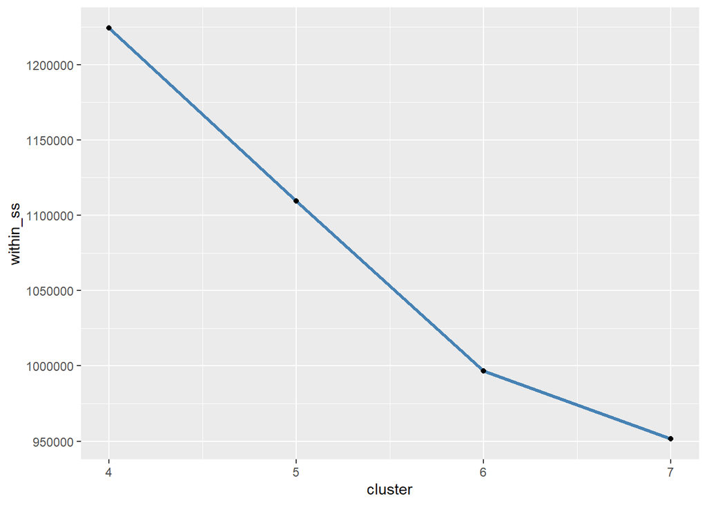

```r
within_ss = sapply(4:7,FUN = function(x) kmeans(x = data_cluster,centers = x,iter.max = 1000,nstart = 25,algorithm="Lloyd")$tot.withinss)
ggplot(data=data.frame(cluster = 4:7,within_ss),aes(x=cluster,y=within_ss))+
  geom_line(col='steelblue',size=1.2)+
  geom_point()+
  scale_x_continuous(breaks=seq(1,10,1))
```

#####Ideal number of clusters is inferred from a change in the line graph what is commonly known as the elbow point. We see the elbow point at cluster = 6 in the above plot relative to other cluster points.

####Ratio plot #####Computing ratio of between cluster sum of squares and total sum of squares for a number of values of k and plotting a line graph against it to infer number of clusters from the elbow point

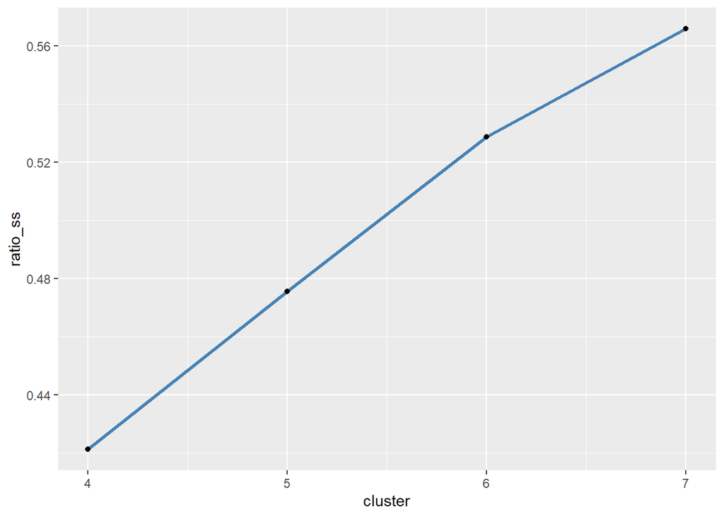

```r
ratio_ss = sapply(4:7,FUN = function(x) {km = kmeans(x = data_cluster,centers = x,iter.max = 1000,nstart = 25,algorithm="Lloyd")
km$betweenss/km$totss} )
ggplot(data=data.frame(cluster = 4:7,ratio_ss),aes(x=cluster,y=ratio_ss))+
  geom_line(col='steelblue',size=1.2)+
  geom_point()+
  scale_x_continuous(breaks=seq(1,10,1))
```

#####We see the elbow point at cluster = 6 in the above plot relative to other cluster points

##### We perform K-Means on a six-cluster solution as both the total within sum of square and ratio plots support that apart from our initial observations of solutions providing extremely small clusters

```r
set.seed(1000)
km = kmeans(x = data_cluster,centers = 6,iter.max=1000,nstart=25,algorithm="Lloyd")

#Size of the clusters
k_segments = km$cluster
table(k_segments)
```

```
## k_segments
##      1      2      3      4      5      6
##   1336  20481   6741  16055    924 104280
```

####Visualizing the Clusters

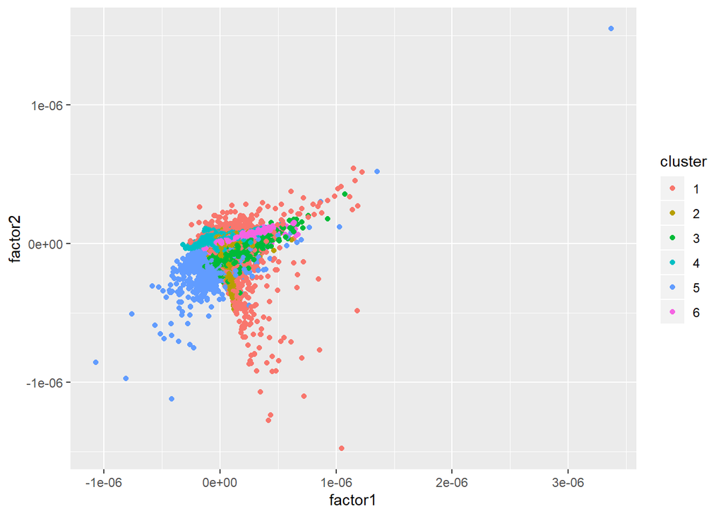

```r
temp = data.frame(cluster = factor(k_segments),
                  factor1 = fa(data_cluster,nfactors = 2,rotate = 'varimax')$scores[,1],
                  factor2 = fa(data_cluster,nfactors = 2,rotate = 'varimax')$scores[,2])
ggplot(temp,aes(x=factor1,y=factor2,col=cluster))+
  geom_point()
```

```r
c=km[1] #Storing cluster mapping in a variable

#Centroids of clusters
km[2]
```

```
## $centers
##          PC1        PC2          PC3         PC4         PC5        PC6
## 1 -11.479435 -1.1542782   3.23508899 -1.01350426 -0.51817909  3.8229182
## 2  -1.024826 -2.2790931   1.11587235  0.10154398 -0.25417565 -0.4767459
## 3  -2.284392  0.4662327  -3.08499913  0.42009610 -2.62191940 -1.1735749
## 4  -3.166774  1.9640448   0.71008952  0.01546949  0.75338197 -0.4197586
## 5  -7.015583 -6.2412116 -11.07382488 -0.25111403  4.14959400  0.3167441
## 6   1.045742  0.1851888  -0.07238736 -0.03427198  0.07328965  0.1823402
##           PC7         PC8
## 1 -0.22207574 -0.44129850
## 2  0.27942639  0.15838910
## 3 -1.05450368 -0.48313287
## 4 -0.13797840  0.11349402
## 5  0.28312794  0.15666711
## 6  0.03486578 -0.01308497
```

```r
#Cluster size
km[7]
```

```
## $size
## [1]   1336  20481   6741  16055    924 104280
```

#####The cluster sizes indicate that clusters 1,5 and 3 correspond to 9001 cases totally which is about 6% of the total observations that need inspection.

###CONCLUSION:

1. Based on the feedback from the last assignment, new features were added to perform peer comparisons on payments and charges among providers of the same state in addition to comparing individual provider’s covered charge to total charge through existing features
2. There is a need to perform Principal Component Analysis for creating new features by combining existing features to avoid higher weightage to a specific dimension measured by multiple variables
3. We arrive at a six-cluster solution using our initial observations of cluster distribution as well as data driven methods like Within sum of squares plot and Ratio plot that rely on measures of distance of points from the clusters they are assigned to
4. Using the average statistics of the variables of the six-cluster solution, we can form an opinion that providers falling in clusters 1 and 5 (1.5% of total cases) deserve a careful and thorough inspection. Cluster 3 (4.5% of total cases) need a preliminary level inspection, the findings from which can be further used for a closer inspection on healthcare abuse
5. The cluster sizes of the six-cluster solution indicate that clusters 1,5 and 3 correspond to 9001 cases totally which is about 6% of the total observations that need inspection for healthcare waste and abuse